# Session 7: Tutorial on Conduct Estimation

2023-07-17

## Overview of QEC9X01

- Session 1: Oligopolistic Competition Refresher
- Session 2: Oligopolistic Competition Refresher (cont.)
- Session 3: Introduction into R and Econometrics
- Session 4: Introduction into R and Econometrics (cont.)
- Session 5: Estimation of Demand for Homogenous Goods
- Session 6: Identification of Conduct and Collusion
- *Session 7: Econometrics Tutorial: Conduct Estimation*
- Session 8: Product Differentiation, Multinomial Logit
- Session 9: Differentiated Demand Workshop
- Session 10: Market Structure and Entry
- Session 11: Merger analysis
- Session 12: Merger analysis - Empirical tutorial in R

## What we do in Session 7

Firms sometimes want to collude to raise their profits

- independent firms behave like one single entity (monopolist)
- internalize demand loss after price raise lost otherwise

No empirical challenge if we know when collusion took place

- quantify price overcharges, e.g., by DiD
- quantify cartel profits by assuming conduct

Big challenges for cartel offices, consulting, research are

- *when* do firms illegally raise prices?
- *how close* are we to full collusion/monopoly?

## Our goal is to screen for collusive prices

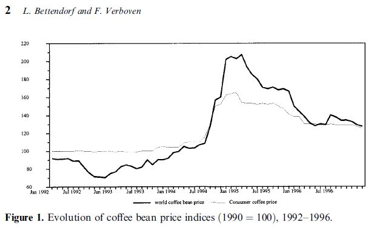

Analysis of *real data* from *real research paper*

- we have a time series of (coffee) price data
- we see a sharp increase in prices
- is this increase due to collusion?

## Data preparation for analysis

We take the same data set as Bettendorf & Verboven (1998)

```r
library(dplyr)
library(zoo)

# load data using package dplyr
coffee_raw <- read.csv("dutch_coffee.csv")

# Convert year/month variable into R time format using package zoo
coffee <- coffee_raw %>%
  mutate(date = as.Date(as.yearmon(month)))
```

NB: We use pipes from package dplyr

- symbol “%>%” means “then”

## Research question: do firms collude?

We plot the prices and get the same picture as before

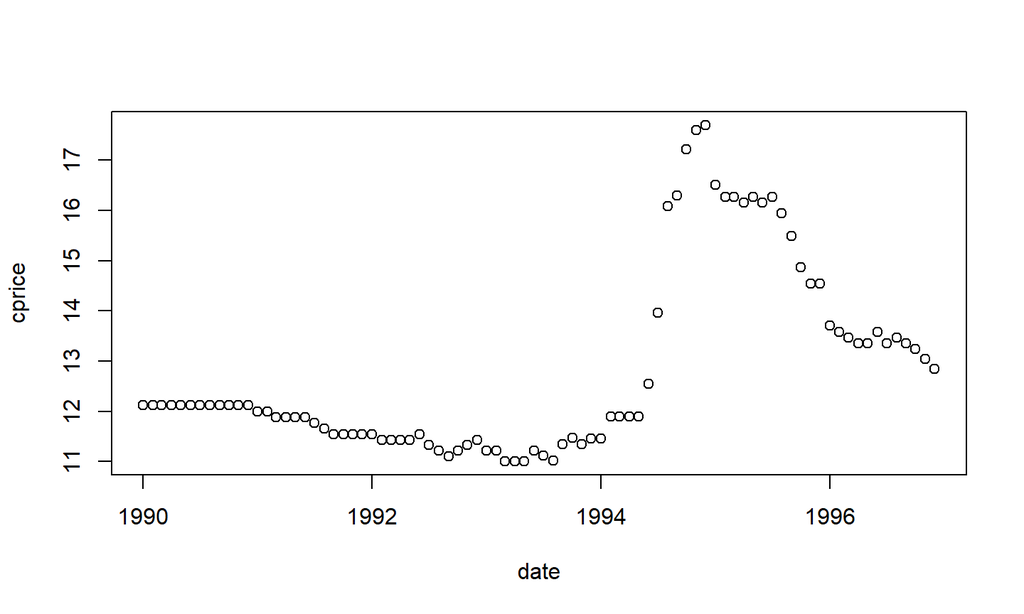

```r
plot(cprice ~ date, coffee)
```

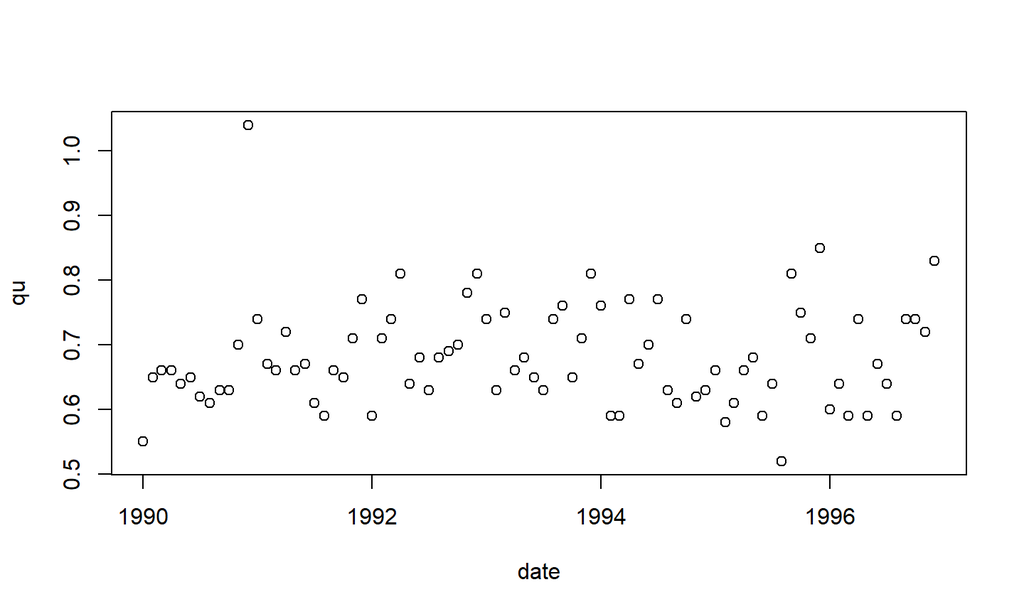

```r
plot(qu ~ date, coffee)
```

## which we can show more analytically

Create data around price spike in 1994 and price decline in 1996

- using function filter from dplyr

```r
coffee_1994= filter(coffee, year==1994)
coffee_1996= filter(coffee, year==1996)
```

## Sample split regressions 1994

```r
lm(qu ~ v3, data = coffee_1994)
```

```
##
## Call:
## lm(formula = qu ~ v3, data = coffee_1994)
##
## Coefficients:
## (Intercept)           v3
##    0.695151    -0.003357
```

## Sample split regressions 1996

```r
lm(qu ~ v3, data = coffee_1996)
```

```
##
## Call:
## lm(formula = qu ~ v3, data = coffee_1996)
##
## Coefficients:
## (Intercept)           v3
##     0.57712      0.01493
```

## What factors could drive price spike?

Can we conclude that there is collusion?

Or could there be other factors?

## Our data contains the variables

| Variable | Description |
| --- | --- |
| qu | per capita consumption of roasted coffee in kg |
| cprice | price of roasted coffee per kg in current guilders |
| tprice | price of per kg tea in current guilders |
| oprice | price of other goods (inflation index) |
| incom | income per capita in current quilders |
| bprice | price of coffee beans per kg in current guilders |
| wprice | price of labor per man hours (work 160 hours per month) |

## Can higher income explain prices?

Plot income per capita over time

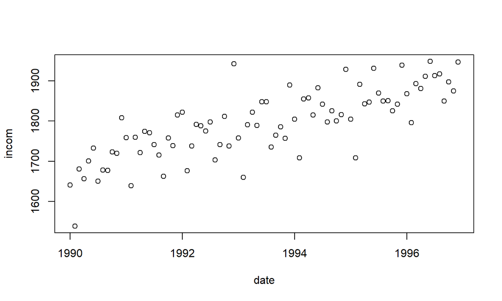

```r
plot(incom ~ date, coffee)
```

## Do substitute products increase prices?

Basic plot of tea price over time:

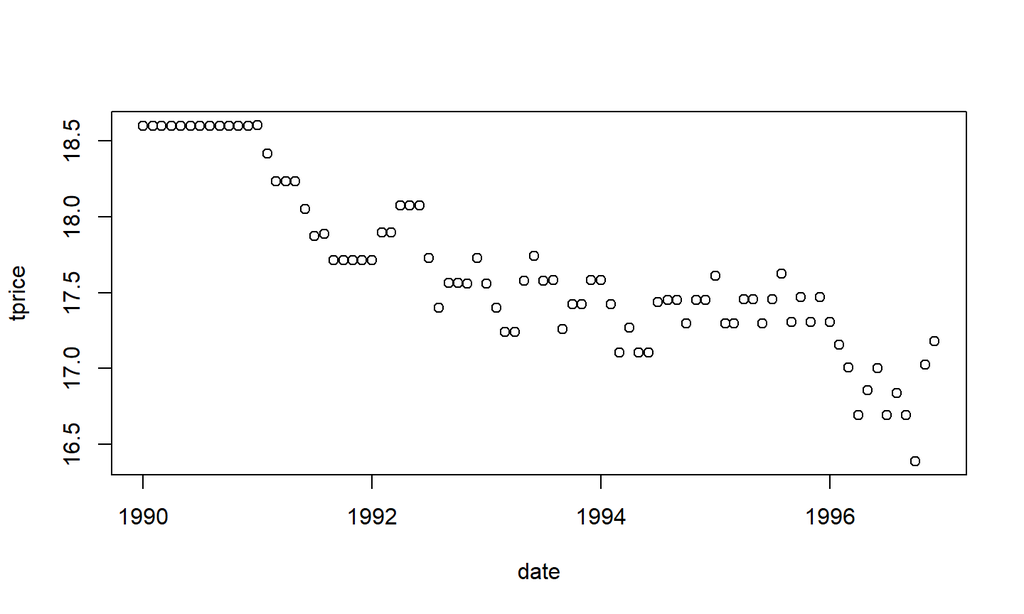

```r
plot(tprice ~ date, coffee)
```

## Do labor costs increase?

Plot wages over time:

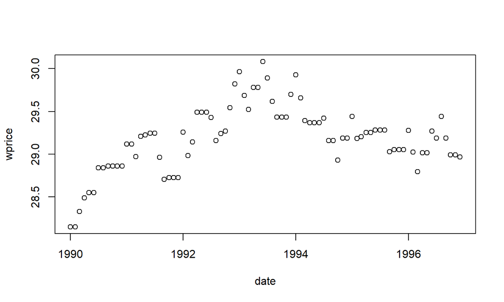

```r
plot(wprice ~ date, coffee)
```

## Do variable costs get more expensive

Plot inflation (prices of all inputs) over time:

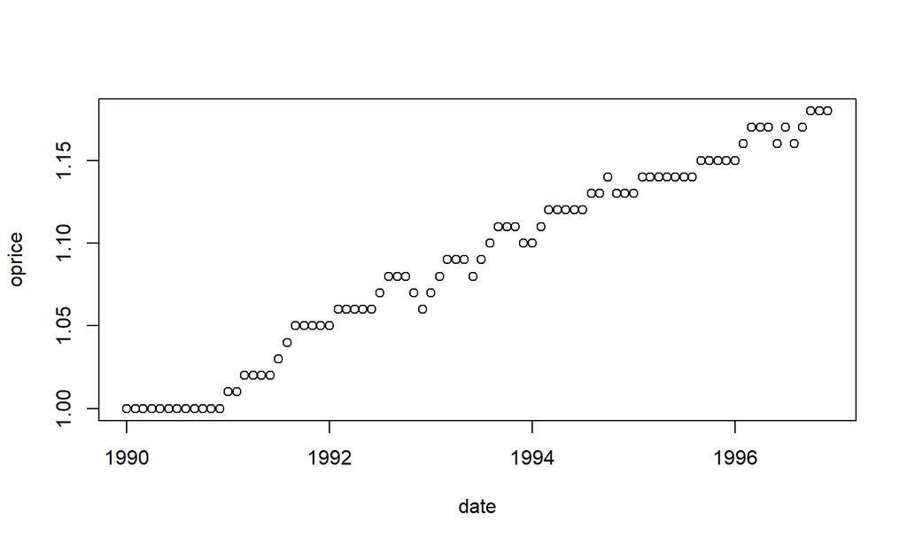

```r
plot(oprice ~ date, coffee)
```

## Now to the obvious

… plot Arabica bean prices over time. What happened in 1994?

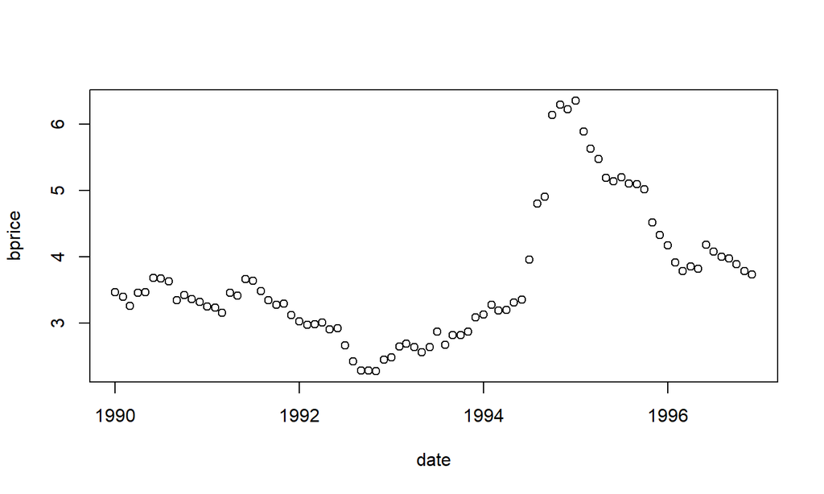

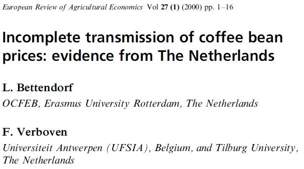

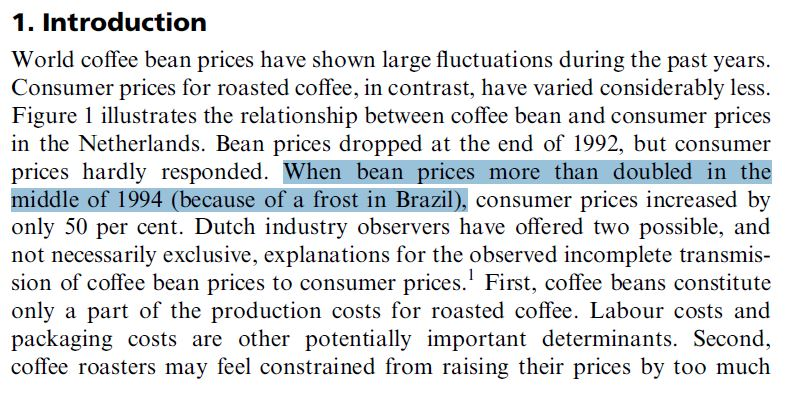

```r
plot(bprice ~ date, coffee)
```

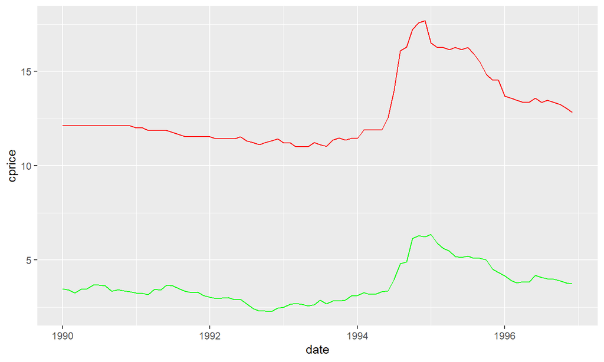

```r
library(ggplot2)
ggplot(coffee, aes(date)) +
  geom_line(aes(y = cprice), colour="red") +
    geom_line(aes(y = bprice), colour="green")
```

## End of story = No collusion?

We have a price spike of input costs. So no collusion?

Theory informs us about pass-through (linear demand)

- *Perfect competition*: \(\frac{d p}{d c}=\) 100%
  - \(p=mc\): every change in \(p\) is equal to change in \(mc\)
- *Monopoly*: \(\frac{d p}{d c}=\) 50%
  - pass-through is half the cost increase since marginal revenue is twice as steep as the demand curve
- *Oligopoy*: 50% \(<\frac{d p}{d c}<\) 100%

## Let us regress prices on costs

```r
lm(log(cprice) ~ log(bprice), data=coffee)
```

```
##
## Call:
## lm(formula = log(cprice) ~ log(bprice), data = coffee)
##
## Coefficients:
## (Intercept)  log(bprice)
##      1.8989       0.5071
```

… and conclude that we have collusion?

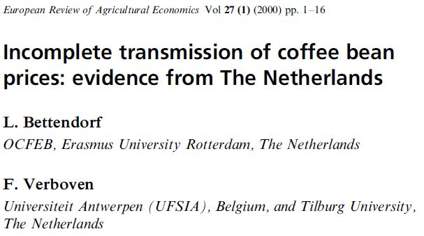

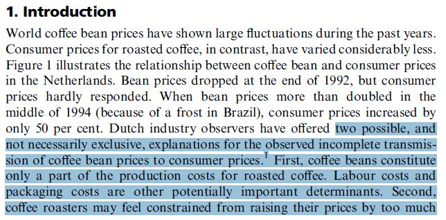

## Roadmap to screen for collusion

Price spike not (only) caused by change in conduct

- i.e., switch fom competition to collusion but also by costs
- *Idea*: exploit variation in input costs to infer conduct
- *Intuition*: decompose price/markup variation into
  - a part explained by cost variation
  - a part explained by elasticities

Everything not explained by costs and elasticity due to conduct

- Cartel indicator: do I internalize behavior of my rival?
- Assume conduct is time-invariant; although firms could collude because of higher input prices (aka Corts critique)

## Roadmap to screen for collusion

Investigate competition in Dutch coffee market (i.e., price spike).

- discriminate between two hypotheses of incomplete pass-on
- using monthly data on Dutch coffee market 1990-1996

To explain competition, we estimate conduct + Lerner Index

- *theoretical concept* of conduct + markup estimation
- markups depends on cost and demand functions
  - *reasonable explanatory variables*
  - *instrumental variables*

## Monopoly problem

Starting with a quantity-setting monopolist facing

- a known inverse demand curve P(Q)
- and costs C(Q)

\[\pi (Q) = P(Q) \cdot Q-C(Q)-F\]

\[\frac{\partial \pi}{\partial Q}=\underbrace{\overbrace{\frac{\partial P(Q)}{\partial Q} \cdot Q}^{Monopoly \\ Distortion}+P(Q)}_{MR}=\underbrace{C'(Q)}_{MC}\] Without monopoly distortion, we are just at \(P=MC\)

## MR has two components

\(MR=\frac{\partial P(Q)}{\partial Q} \cdot Q + P(Q)\)

- When I sell an extra unit, I collect price \(P\) on that unit
- Selling an extra unit changes the market-clearing price \(\frac{\partial P(Q)}{\partial Q}\)
  - change in market-clearing price applied to all units \(Q\)

Monopoly prices given by \(P(Q)=MC+\frac{\partial P(Q)}{\partial Q} Q\)

\(\frac{\partial P(Q)}{\partial Q}<0\), monopolist restricts output to collect a higher price.

## Lerner Index in Monopoly

We take the optimality condition: \[\frac{\partial P(Q)}{\partial Q} \cdot Q+P(Q)=C'(Q)\]

Rearrange and divide by P(Q):

\[\frac{P(Q)-C'(Q)}{P(Q)}=-\frac{\partial P(Q)}{\partial Q} \cdot \frac{Q}{P(Q)}\equiv \frac{1}{|\epsilon_D|}\]

Neat: infer monopoly markup from estimating elasticity \(\epsilon_D\)

- estimate a demand model to obtain elasticity (\(|\epsilon_D|>1\))

## Cournot Model / Nash in quantities

We consider profits \(\pi_i(q_i) = P(Q(q_i))\cdot q_i-C_i(q_i)\)

- where \(Q(q_i)=\sum_{i=1}^{N}q_i\) is the total industry output

\[\frac{\partial \pi_i(q_i)}{\partial q_i}=P(Q)+q_i \cdot \frac{\partial P(Q)}{\partial Q} \cdot \frac{\partial Q}{\partial q_i} = C'(q_i)\]

Cournot competition implies \(\frac{\partial Q}{\partial q_i}=1\) and \(\frac{\partial q_j}{\partial q_i}=0\) for \(i \neq j\)

- when I produce 1 more unit, total output increases by 1 unit
- My opponent cannot react to me producing 1 more unit
  - This is due to simultaneous moves in Cournot

## Cournot optimality and Lerner Index

Under symmetry, all firms produce equal quantities \(q_i=\frac{Q}{N}\)

\[\underbrace{\overbrace{\frac{\partial P(Q)}{\partial Q}*\frac{Q}{N}}^{Cournot \\ Distortion}+P(Q)}_{MR}=\underbrace{C'(Q)}_{MC}\]

- in Monopoly, we had the same thing with \(N=1\)

Rearrange and divide by P(Q) to form Lerner Index

\[\frac{P-MC}{P}=-\frac{1}{N}\frac{Q}{P}\frac{\partial P(Q)}{\partial Q}=-\frac{1}{N \cdot \epsilon_D}\]

## Complaint about Cournot:

If I change my quantity, why doesn’t my rival react?

Assume competitors react in \(q\), then \(\frac{\partial Q}{\partial q_i}=1+\frac{\partial Q_{-i}}{\partial q_i}\)

*Marginal Revenue* becomes: \(P(Q)+\frac{\partial P(Q)}{\partial Q} \cdot q_i \cdot (\underbrace{1+\frac{\partial Q_{-i}}{\partial q_i}}_{Conduct~\theta_i})\)

- \(\frac{\partial Q_{-i}}{\partial q_i}= -1\): Perfect competition (no change of aggregate Q )
- \(\frac{\partial Q_{-i}}{\partial q_i}= 0\): Cournot with simultaneous moves
- \(\frac{\partial Q_{-i}}{\partial q_i}= N-1\): Collusion (increase by \(N\) if I increase by 1)

\(\theta_i\) *conjecture* (=belief) about how my rival is going to respond

## Intutition:

I want to estimate how competitors react to my demand change

if competitors:

- reduce their quantity: likely perfect competition
- do not react: likely Cournot
- also increase quantity: likely collusion

## Estimation of conduct parameter

… using *conjectures* (=beliefs about my rivals behavior)

We know that this relation holds in optimum:

\[P(Q)+\frac{\partial P(Q)}{\partial Q} \cdot q_i \cdot (\underbrace{1+\frac{\partial Q_{-i}}{\partial q_i}}_{Conduct~\theta_i})= C'(Q)\]

We can obtain unknown *conduct* \(\theta_i\) if we

- know prices \(P\) and quantities \(q_i\)
- have information on marginal costs \(C'(Q)\)
- and estimate how prices change with quantity

because *conduct* \(\theta_i\) is the only unknown in this equation

## Normalized conduct parameter

We can rewrite the above expression and multiply by \(\frac{Q}{Q}\) to get

\[P(Q)+\frac{\partial P(Q)}{\partial Q} \cdot Q \underbrace{\frac{q_i}{Q} \cdot (1+\frac{\partial Q_{-i}}{\partial q_i}}_{Normalized~Conduct~\phi_i})= C'(Q)\]

- with symmetry market share becomes: \(\frac{q_i}{Q}=\frac{1}{N}\)
- where conduct is weigthted by market share: \(0\leq\phi\leq 1\)

The conduct parameter can take the following values:

- \(\phi = 0\) for perfect competition
- \(0 < \phi < 1\) for oligopoly
- \(\phi = 1\) for monopoly or collusion

## How to infer normalized conduct \(\phi\)

Rewrite FOC as Lerner Index: \(L=\frac{P-MC}{P}=\frac{\phi}{\epsilon_D}\). Solve for \(\phi\)

\[ \phi = −\epsilon_D \frac{P-MC}{P} \equiv L_{\epsilon}\]

\(\epsilon_D\) is the elasticity of demand and \(L_{\epsilon}\) is also called Lerner index adjusted for elasticity (Genesove and Mullin, 1998).

We can thus estimate conduct \(\phi\) if we have information on

- market clearing price \(P\) (usually known)
- marginal costs \(MC\) (either known or estimated)
- elasticities \(\epsilon_D=\frac{\partial Q}{\partial P} \cdot \frac{P}{Q}\) (usually estimated)

## We infer conduct in two ways

In both ways, we need to estimate elasticity

- unless we have access to surveys or other studies

*Way No 1*: use marginal cost estimates from industry

- this is also called: parametrize marginal costs \(MC\)

*Way No 2*: Solving adjusted Lerner index for market prices

- as function of conduct parameter \(\phi\), elasticity \(\epsilon_D\), and costs:

\[P(c) = \frac{\epsilon_D}{\epsilon_D + \phi} c\]

We can now regress prices on marginal costs (conditional on \(\epsilon_D\))

## Solving for conduct: prices on costs

Obtaining \(\phi\) from our coefficient on cost (\(b\))

\[b=\frac{\epsilon_D}{\epsilon_D + \phi}\]

Rearranging:

\[\epsilon_D=b(\epsilon_D + \phi)\]

\[b\phi = \epsilon_D − b\epsilon_D \]

\[\phi = \frac{\epsilon_D(1 − b)}{b}\]

## Choosing demand and supply models

How can we now bring the theoretical insights to data?

## Choosing demand and supply models

As stated before, we need to make assumption on demand and costs to obtain conduct

- Usually we observe \(P\) and \(Q\)
- But we do not know the slope of the demand function \(\frac{\partial Q}{\partial P}\)
- And we rarely have access to information on marginal costs
  - accounting data not available at product level and usually inaccurate due to reporting bias
  - in many cases, we estimate the marginal cost function

## Assumption demand function

We consider the following two demand functions

| Model | Transformed demand | Own-price elasticity |
| --- | --- | --- |
| Linear | \(Q = \alpha + \beta P + \gamma X\) | \(\varepsilon = \beta ∗ P/Q\) |
| Log-log | \(log(Q) = \alpha + \beta log(P) + \gamma log(X)\) | \(\varepsilon = \beta\) |

This is of course an arbitrary choice. Normally, we need to

- validate with other studies
- cross-check with evidence from industry
- provide robustness checks

## Assumption production technology

We assume that (constant) marginal costs for coffee are:

\[c = c_0 + k P_{coffeebeans} \]

- \(c_0\): all costs other than coffee beans (e.g., labour, packages)
- \(k\): how input prices of coffee beans enter cost function

*Approach 1*: Use estimates from Bettendorf & Verboven (1998)

- their parameters are confirmed by industry wisdom
- \(c_0\) around 4 guilders.
- \(k\) one kg of roasted coffee requires 1.19 kg of beans.

*Approach 2*: Regress prices on costs to estimate parameters

## Estimating demand to obtain conduct \(\phi\)

## Basic demand regression (log-log)

Simple regression without IV

```r
q_p1 <- lm(log(qu)
           ~ log(cprice) + q2 + q3 + q4
           , coffee)
```

```r
summary(q_p1)
```

```
##
## Call:
## lm(formula = log(qu) ~ log(cprice) + q2 + q3 + q4, data = coffee)
##
## Residuals:
##      Min       1Q   Median       3Q      Max
## -0.18748 -0.06386 -0.01282  0.05953  0.33462
##
## Coefficients:
##             Estimate Std. Error t value Pr(>|t|)
## (Intercept)  0.05142    0.20559   0.250   0.8032
## log(cprice) -0.19087    0.08088  -2.360   0.0207 *
## q2           0.03631    0.03059   1.187   0.2389
## q3           0.01072    0.03066   0.349   0.7277
## q4           0.12938    0.03070   4.214 6.61e-05 ***
## ---
## Signif. codes:  0 '***' 0.001 '**' 0.01 '*' 0.05 '.' 0.1 ' ' 1
##
## Residual standard error: 0.09913 on 79 degrees of freedom
## Multiple R-squared:  0.2499, Adjusted R-squared:  0.212
## F-statistic: 6.581 on 4 and 79 DF,  p-value: 0.0001267
```

## Including tea price:

```r
q_p2 <- lm(log(qu)
           ~ log(cprice) + q2 + q3 + q4 + log(tprice)
           , coffee)
```

```r
summary(q_p2)
```

```
##
## Call:
## lm(formula = log(qu) ~ log(cprice) + q2 + q3 + q4 + log(tprice),
##     data = coffee)
##
## Residuals:
##      Min       1Q   Median       3Q      Max
## -0.18231 -0.06489 -0.01180  0.06300  0.34976
##
## Coefficients:
##              Estimate Std. Error t value Pr(>|t|)
## (Intercept)  0.941587   1.166057   0.807   0.4218
## log(cprice) -0.211563   0.085362  -2.478   0.0154 *
## q2           0.035331   0.030695   1.151   0.2532
## q3           0.008734   0.030848   0.283   0.7778
## q4           0.127478   0.030877   4.129 9.08e-05 ***
## log(tprice) -0.291391   0.375691  -0.776   0.4403
## ---
## Signif. codes:  0 '***' 0.001 '**' 0.01 '*' 0.05 '.' 0.1 ' ' 1
##
## Residual standard error: 0.09938 on 78 degrees of freedom
## Multiple R-squared:  0.2557, Adjusted R-squared:  0.208
## F-statistic: 5.359 on 5 and 78 DF,  p-value: 0.0002755
```

## Include income:

```r
q_p3 <- lm(log(qu)
           ~ log(cprice) + q2 + q3 + q4 + log(tprice) + log(incom)
           , coffee)
```

```r
summary(q_p3)
```

```
##
## Call:
## lm(formula = log(qu) ~ log(cprice) + q2 + q3 + q4 + log(tprice) +
##     log(incom), data = coffee)
##
## Residuals:
##      Min       1Q   Median       3Q      Max
## -0.19669 -0.07418 -0.00985  0.06009  0.32008
##
## Coefficients:
##              Estimate Std. Error t value Pr(>|t|)
## (Intercept) -5.066677   3.785234  -1.339  0.18466
## log(cprice) -0.257084   0.088716  -2.898  0.00489 **
## q2           0.016153   0.032460   0.498  0.62017
## q3           0.004408   0.030613   0.144  0.88587
## q4           0.108703   0.032544   3.340  0.00129 **
## log(tprice)  0.281420   0.506109   0.556  0.57979
## log(incom)   0.599462   0.359717   1.666  0.09968 .
## ---
## Signif. codes:  0 '***' 0.001 '**' 0.01 '*' 0.05 '.' 0.1 ' ' 1
##
## Residual standard error: 0.09827 on 77 degrees of freedom
## Multiple R-squared:  0.2816, Adjusted R-squared:  0.2256
## F-statistic:  5.03 on 6 and 77 DF,  p-value: 0.000213
```

## Instrumental variable regressions

Recap: Why do we need an instrument?

Which instrument could be used?

```r
library("AER")

iv2 <- ivreg(log(qu)
             ~ q2 + q3 + q4 + log(incom) + log(tprice) + log(cprice)
             | log(bprice) + q2 + q3 + q4 + log(incom) + log(tprice)
             , data = coffee)
```

```r
summary(iv2)
```

```
##
## Call:
## ivreg(formula = log(qu) ~ q2 + q3 + q4 + log(incom) + log(tprice) +
##     log(cprice) | log(bprice) + q2 + q3 + q4 + log(incom) + log(tprice),
##     data = coffee)
##
## Residuals:
##      Min       1Q   Median       3Q      Max
## -0.19282 -0.07589 -0.01115  0.06385  0.31893
##
## Coefficients:
##              Estimate Std. Error t value Pr(>|t|)
## (Intercept) -5.219679   3.791813  -1.377  0.17264
## q2           0.015129   0.032500   0.466  0.64287
## q3           0.004497   0.030627   0.147  0.88366
## q4           0.108218   0.032564   3.323  0.00136 **
## log(incom)   0.628211   0.361700   1.737  0.08642 .
## log(tprice)  0.280218   0.506333   0.553  0.58158
## log(cprice) -0.280111   0.093395  -2.999  0.00364 **
## ---
## Signif. codes:  0 '***' 0.001 '**' 0.01 '*' 0.05 '.' 0.1 ' ' 1
##
## Residual standard error: 0.09831 on 77 degrees of freedom
## Multiple R-Squared: 0.281,   Adjusted R-squared: 0.2249
## Wald test: 5.127 on 6 and 77 DF,  p-value: 0.0001775
```

## Way 1: Cost information from industry to obtain conduct \(\phi\)

## Calculate learner index

… with cost from Bettendorf & Verboven + our estimate of \(\epsilon_D\)

- without knowing the actual number of firms

```r
epsilon_D = -0.28

k = 1.19 # kg of beans per kg of coffee
c0= 4 # by assumption (4 guilders)

# obtain the cost function
cost = c0 + k*coffee$bprice

# compute Lerner index
Lerner= (coffee$cprice - cost) / coffee$cprice
summary(Lerner)
```

```
##    Min. 1st Qu.  Median    Mean 3rd Qu.    Max.
##  0.2919  0.3329  0.3459  0.3467  0.3601  0.4073
```

## Calculate adjusted learner index

i.e., our conduct parameter with cost from Bettendorf & Verboven + our estimate of \(\epsilon_D\):

```r
# now compute adjusted Lerner index
Lerner_adj = -epsilon_D * Lerner
summary(Lerner_adj)
```

```
##    Min. 1st Qu.  Median    Mean 3rd Qu.    Max.
## 0.08172 0.09321 0.09685 0.09707 0.10082 0.11404
```

Although the markup is rather high, conduct is relatively low

- high markups driven by elasticity rather than collusion

## Way 2: Estimate costs to obtain conduct \(\phi\)

Remember that we have: \(P=\frac{\epsilon_D}{(\epsilon_D+\phi)}MC\)

- which we get from regression of prices on costs

## Naive cost specification

```r
lm(cprice ~ bprice - 1, data = coffee) # omits intercept
```

```
##
## Call:
## lm(formula = cprice ~ bprice - 1, data = coffee)
##
## Coefficients:
## bprice
##  3.374
```

## Now we can back out conduct

… by solving for \(\phi\) as above

```r
# estimated coefficient from costs
b1=3.3

# conduct
phi1=epsilon_D*(1-b1)/b1
mean(phi1)
```

```
## [1] 0.1951515
```

## Full cost specification

```r
lm(cprice ~ bprice + wprice + oprice - 1, data = coffee)
```

```
##
## Call:
## lm(formula = cprice ~ bprice + wprice + oprice - 1, data = coffee)
##
## Coefficients:
## bprice  wprice  oprice
##  1.693   0.081   3.896
```

```r
# estimated coefficient from costs
b2=1.69

# conduct
phi2=epsilon_D*(1-b2)/b2
mean(phi2)
```

```
## [1] 0.1143195
```

## Robustness check: Linear demand

## Linear demand

```r
linear1 <- ivreg(qu
                 ~ cprice + incom + q1 + q2 + q3
                 | bprice + incom + q1 + q2 + q3
                 , data = coffee)
```

## Linear demand

```r
summary(linear1)
```

```
##
## Call:
## ivreg(formula = qu ~ cprice + incom + q1 + q2 + q3 | bprice +
##     incom + q1 + q2 + q3, data = coffee)
##
## Residuals:
##      Min       1Q   Median       3Q      Max
## -0.10980 -0.04802 -0.01128  0.03786  0.28995
##
## Coefficients:
##               Estimate Std. Error t value Pr(>|t|)
## (Intercept)  0.5586704  0.1763239   3.168 0.002189 **
## cprice      -0.0137198  0.0047471  -2.890 0.004985 **
## incom        0.0001979  0.0001059   1.868 0.065561 .
## q1          -0.0792122  0.0227557  -3.481 0.000821 ***
## q2          -0.0687351  0.0216801  -3.170 0.002176 **
## q3          -0.0759836  0.0220445  -3.447 0.000917 ***
## ---
## Signif. codes:  0 '***' 0.001 '**' 0.01 '*' 0.05 '.' 0.1 ' ' 1
##
## Residual standard error: 0.06993 on 78 degrees of freedom
## Multiple R-Squared: 0.2752,  Adjusted R-squared: 0.2287
## Wald test: 5.993 on 5 and 78 DF,  p-value: 9.637e-05
```

## Adj. learner index with linear demand

```r
epsilon_D_lin=-0.014*coffee$cprice/coffee$qu

phi1_lin=-epsilon_D_lin*Lerner
phi2_lin=epsilon_D_lin*(1-b2)/b2 # full cost

summary(phi1_lin)
```

```
##    Min. 1st Qu.  Median    Mean 3rd Qu.    Max.
## 0.05612 0.08010 0.08783 0.09288 0.09777 0.15810
```

```r
summary(phi2_lin)
```

```
##    Min. 1st Qu.  Median    Mean 3rd Qu.    Max.
## 0.06661 0.09398 0.10305 0.10929 0.11621 0.17530
```

## Example: Bettendorf & Verboven

[figure not shown]

## Critique

so we hold supply fixed and move around the demand curve (shocks).

given that supply is fixed, we can draw supply curve at different points when demand changes

but we need to assume that conduct is fixed (e.g., collusion) which is a difficult assumption (Corts critique)

- collusive conduct could be difficult to sustain with higher demand shocks (Corts critique)
- or firms may start to collude when input prices increase